# Tarea: JAGS

Daniel Camarena

### 1. Inferencia de dos proporciones binomiales

Consideramos la situación en la que nos interesa estudiar dos proporciones $\theta_1$ y $\theta_2$ correspondientes a dos grupos, este es el ejemplo que vimos en clase con distribuciones conjugadas, Metropolis y Gibbs.

Ahora implementalo en JAGS:

- Asigna una distribución inicial Beta(3, 3) a cada una de las proporciones (vas a suponer independencia de nuestras creencias iniciales).
- Las observaciones están dadas por el siguiente `data.frame`, consisten en el resultado de 14 lanzamientos, 7 de cada moneda, en la primera observamos 5 águilas y en la segunda 2.

```r
library(dplyr)
library(ggplot2)
library(gridExtra)
library(R2jags)

observaciones <- data_frame(
    moneda = c(rep(1, 7), rep(2, 7)),
    x = c(rep(0, 2), rep(1, 5), rep(0, 5), rep(1, 2))
    )
```

Tip:

El siguiente código especifica el modelo, debes sustituir las `X` con los valores de acuerdo a tu script.

```r
library(R2jags)

# N: número de volados (total), M: número de monedas
modelo_1.bugs <-
'
model{
    for(i in 1:N){
        x[i] ~ dbern(theta[moneda[i]])
    }
    # inicial
    for(m in 1:nCoins){
        theta[m] ~ dbeta(3, 3)
    }
}
'

# especificamos los valores iniciales
jags.inits <- function(){list("mu" = runif(1, 0.1, 0.9), "kappa" = runif(1, 5, 20))}

# especificamos los datos iniciales
jags.data <- list(x = observaciones$x, moneda = observaciones$moneda, nCoins = 2, N = nrow(observaciones))

# especificamos los parámetros a monitorear
jags.parameters <- c("theta")

# ajustamos el modelo
jags.fit <- jags(model.file = textConnection(modelo_1.bugs),
                 inits = jags.inits,
                 data = jags.data,
                 parameters.to.save = jags.parameters,
                 n.chains = 3,
                 n.iter = 10000,
                 n.burnin = 1000)
```

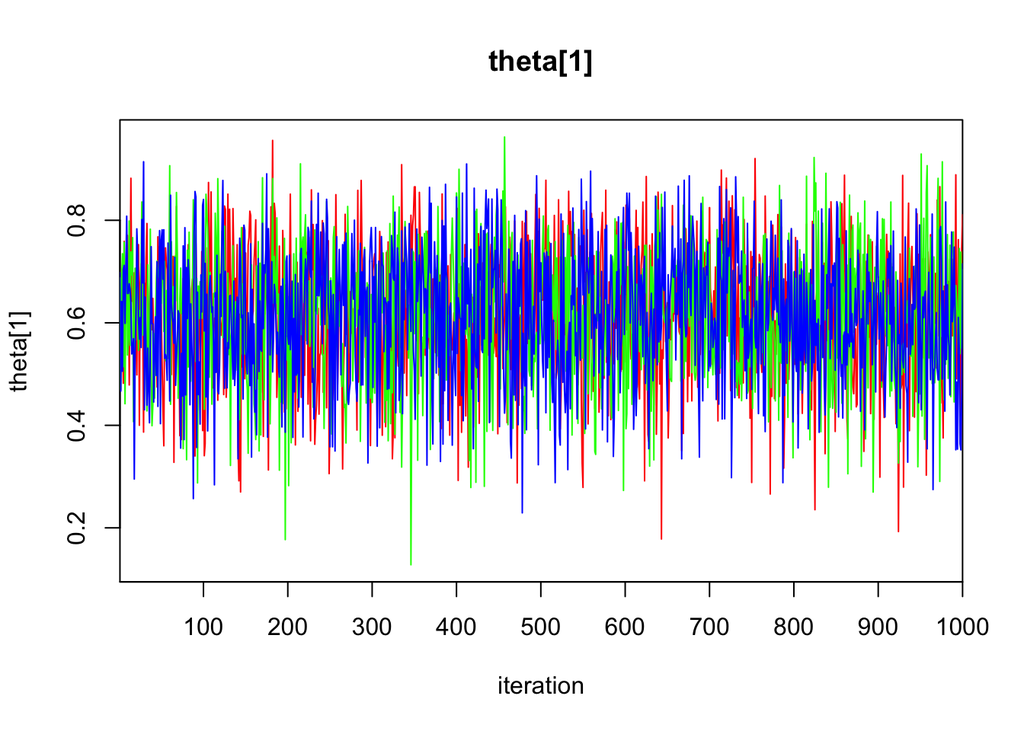

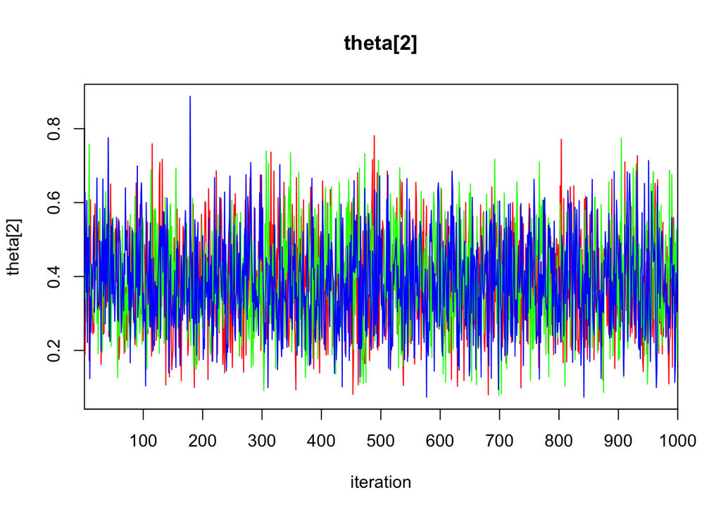

```r
# monitoreamos la cadena de theta
traceplot(jags.fit, varname = c("theta"))
```

```r
# resumen del ajuste
jags.fit
```

```
## Inference for Bugs model at "5", fit using jags,
##  3 chains, each with 10000 iterations (first 1000 discarded), n.thin = 9
##  n.sims = 3000 iterations saved
##          mu.vect sd.vect   2.5%    25%    50%    75%  97.5%  Rhat n.eff
## theta[1]   0.614   0.129  0.351  0.528  0.617  0.710  0.849 1.001  3000
## theta[2]   0.385   0.131  0.152  0.289  0.380  0.475  0.654 1.002  1400
## deviance  18.376   1.544 16.799 17.265 17.940 19.010 22.323 1.001  3000
##
## For each parameter, n.eff is a crude measure of effective sample size,
## and Rhat is the potential scale reduction factor (at convergence, Rhat=1).
##
## DIC info (using the rule, pD = var(deviance)/2)
## pD = 1.2 and DIC = 19.6
## DIC is an estimate of expected predictive error (lower deviance is better).
```

### 2. Regresión

Implementaremos un modelo de regresión en JAGS, la base de datos que usaremos contiene información de mediciones de radón (activity) y del suelo en el que se hicieron las mediciones (floor = 0 casas con sótano, floor = 1 casas sin sótano), las mediciones corresponden a 919 hogares muestreados de 85 condados de Minnesota. El objetivo es construir un modelo de regresión en el que la medición de radón es la variable dependiente y el tipo de suelo es la covariable.

El modelo es como sigue:

$$y_i \sim N(\alpha + \beta x_i, \sigma^2)$$

La distribuciones iniciales que usaremos son:

```r
modelo_regresion.bugs <-
'
model{
  for(i in 1 : n) {
    y[i] ~ dnorm(y.hat[i], tau.y)
    y.hat[i] <- a + b * x[i]
  }
  a ~ dnorm(0, 0.001)
  b ~ dnorm(0, 0.001)
  tau.y <- pow(sigma.y, -2)
  sigma.y ~ dunif(0, 100)
}
'
cat(modelo_regresion.bugs, file = 'modelo_regresion.bugs')

### Radon
load("radon.Rdata")

# Iniciamos preparando los datos para el análisis, trabajaremos en
# escala logarítmica, hay algunos casos con medición cero, para éstos
# hacemos una pequeña correción redondeándolos a 0.1.
y <- log(ifelse (radon.2$activity == 0, 0.1, radon.2$activity))

# jags
data_radon <- list(n = nrow(radon.2), y = y, x = radon.2$floor)

inits_radon <- function(){
  list(a = rnorm(1),
  b = rnorm(1),
  sigma.y = runif(1))}

parameters_radon <- c("a", "b", "sigma.y")
```

- El ejercicio consiste en que definas número de cadenas, número de iteraciones y etapa de calentamiento en la siguiente instrucción. Asegurate de alcanzar convergencia y describe los diagnósticos que utilizaste para concluir que se convergió a la distribución posterior.

```r
jags_radon <- jags(
  data = data_radon,
  inits= inits_radon,
  parameters.to.save = parameters_radon,
  model.file = "modelo_regresion.bugs",
  n.chains=1,
  n.iter = 100000,
  n.burnin = 10000)

out <- jags_radon$BUGSoutput$sims.list

a1 <- zz <- out$a %>%
  as_data_frame() %>%
  ggplot(aes(.)) +
  geom_histogram(bins = 15, alpha = 0.5)

a2 <- (cumsum(out$a)/(1:length(out$a))) %>%
  as_data_frame() %>%
  ggplot(aes(x = seq(1, length(out$a), 1), y = .)) +
  geom_line()

grid.arrange(a1, a2, nrow = 1)

b1 <- zz <- out$b %>%
  as_data_frame() %>%
  ggplot(aes(.)) +
  geom_histogram(bins = 15, alpha = 0.5)

b2 <- (cumsum(out$b)/(1:length(out$b))) %>%
  as_data_frame() %>%
  ggplot(aes(x = seq(1, length(out$b), 1), y = .)) +
  geom_line()

grid.arrange(b1, b2, nrow = 1)
```

[output not shown]

- El modelo anterior ignora la variación en los niveles de radón entre los condados. Modifica el modelo para permitir variación, es decir, el modelo será (modelo de unidades independientes):

$$y_i \sim N(\alpha_{j[i]} + \beta x_i, \sigma_y^2)$$

- Grafica las estimaciones de $\alpha_{j}$ para los distintos condados.

```r
modelo_regresion.bugs <-
'
model{
  for(i in 1 : n) {
    y[i] ~ dnorm(y.hat[i], tau.y)
    y.hat[i] <- a[cty[i]] + b * x[i]
  }
  for(j in 1:nn){
    a[j] ~ dnorm(0, 0.001)
  }
  b ~ dnorm(0, 0.001)
  tau.y <- pow(sigma.y, -2)
  sigma.y ~ dunif(0, 100)
}
'
cat(modelo_regresion.bugs, file = 'modelo_regresion.bugs')

### Radon
load("radon.Rdata")

# Iniciamos preparando los datos para el análisis, trabajaremos en
# escala logarítmica, hay algunos casos con medición cero, para éstos
# hacemos una pequeña correción redondeándolos a 0.1.
y <- log(ifelse (radon.2$activity == 0, 0.1, radon.2$activity))

# creamos una variable auxiliar con los niveles de los condados para poder
# usar los respectivos índices
cty <- as.integer(as.factor(radon.2$cntyfips))

# número de condados en la base
nn <- length(unique(radon.2$cntyfips))

# jags
data_radon <- list(n = nrow(radon.2), nn = nn, y = y, x = radon.2$floor, cty = cty)

inits_radon <- function(){
  list(a = rnorm(nn),
  b = rnorm(1),
  sigma.y = runif(1))}

parameters_radon <- c("a", "b", "sigma.y")

jags_radon <- jags(
  data = data_radon,
  inits= inits_radon,
  parameters.to.save = parameters_radon,
  model.file = "modelo_regresion.bugs",
  n.chains = 3,
  n.iter = 50000,
  n.burnin = 5000)
```

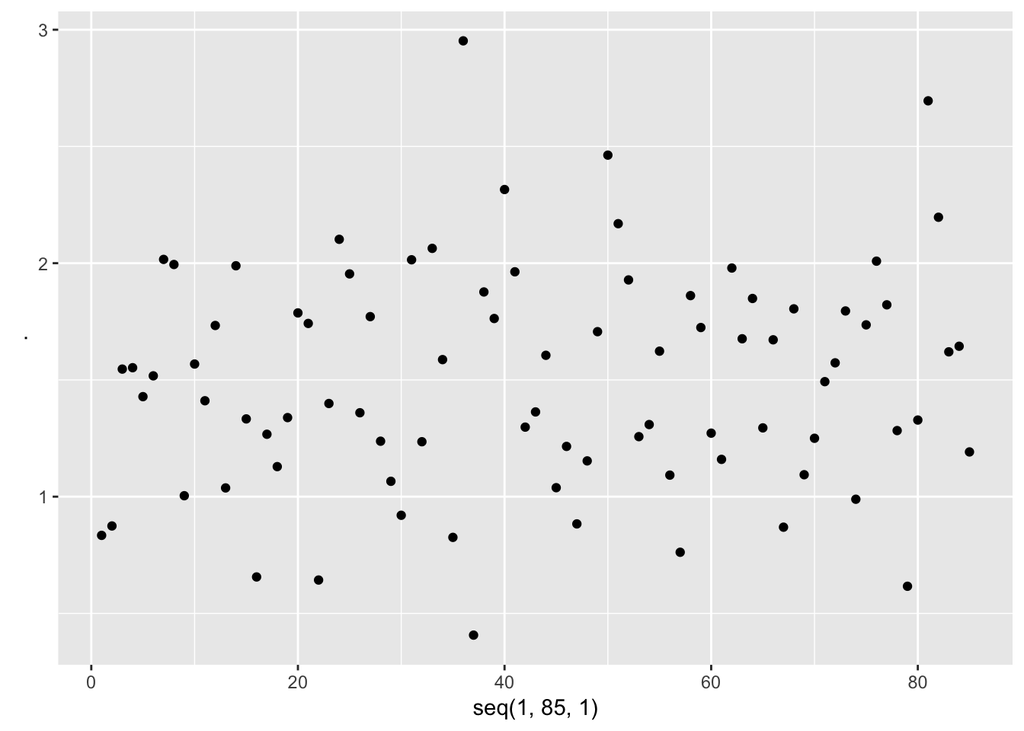

```r
# gráfica de las alfas para los distintos condados
jags_radon$BUGSoutput$summary[1:85,1] %>%
  as_data_frame() %>%
  ggplot(aes(x = seq(1, 85, 1), y = .)) +
  geom_point()
```